{% raw %}

{% endraw %}

## Background

### Example Dataset

The example dataset used in this tutorial contains 2D immunofluorescence images of the *Drosophila* intestine obtained using a spinning-disc confocal microscope. The dataset is describes a "MARCM" experiment from the following [paper](https://doi.org/10.1016/j.celrep.2020.108423).

MARCM is a genetic technique whereby mitotic recombination generates GFP-marked homozygous mutant cells from heterozygous precursors. Over time, individually marked cells divide adjacent to each other and create "clones" of mutant cells, surrounded by unmarked wild-type cells:

{% include image.html width="800" max-width="800" file="/py_clone_detective/docs/images/marcm_explanation.png" %}

> Left:Genetic labelling by MARCM. Right: Labelled cells grow over time into 'clones'.

In this dataset, intestines were imaged using four channels:

- C0 : DAPI (nuclear marker)
- C1 : GFP (clone marker)
- C2 : PDM1 staining (EnteroCyte marker)
- C3 : Prospero staining (EndoEndocrine marker)

{% include image.html width="400" max-width="400" file="/py_clone_detective/docs/images/marcm_slide2-01.png" %}

> composite image

### Experimental Aim

Dataset images contain cells positive for an EnteroCyte marker, cells positive for an EnteroEndocrine marker, and cells negative for both - stem/progenitor cells.

We aim to:

- Quantify the number and type of cells present in each image.
- Classify whether each cell resides outside or inside a clone.

As only cells inside a clone are mutant for our gene of interest, we can determine if our gene of interest regulates **cell differentiation** by comparing the percentage of each cell type inside vs. outside a clone. We can measure if our gene of interest regulates **cell proliferation** by comparing the number of cells per mutant clone, to the number of cells per control clone i.e. clones generated in wild-type animals lacking any mutation.

## Walkthrough

### Initiate Dask dashboard (optional)

Most functions in py_clone_detector are parallelised using [Dask](https://dask.org/). When using the Dask distributed scheduler, we can access an interactive dashboard that details our computations' status, progress, and history. While especially useful when working on a remote cluster, the interactive dashboard is a great addition even when working locally (e.g. MacBook).

For example, here is what the dashboard looks like when measuring cell properties using the `CloneCounter.make_measurements()`) call described below. Each line of the 'Task Stream' corresponds to one of 8 logical cores on my MacBook Pro.

[figure not shown]

> example Dask dashboard

**N.B.** Initiating a Dask scheduler is optional when working on your local machine. If you don't launch one, all computations will still run; you just won't have access to the fancy dashboard!

Launch the scheduler as follows on your local machine and click on the dashboard link:

{% raw %}

```python
%%capture
from dask.distributed import Client

c = Client()
c
```

{% endraw %}

{% include image.html file="/py_clone_detective/docs/images/client_setup.png" %}

If you're working on a remote cluster, e.g. a SLURM HPC, please see the relevant [Dask guides](https://jobqueue.dask.org/en/latest/index.html).

### Import and instantiate CloneCounter subclass:

The LazyCloneCounter subclass uses Dask to lazy load image series that may be too large to fit in RAM. If your data is small enough to fit into RAM, you can speed things up using the PersistentCloneCounter subclass.

For more details, see the advanced tutorial (coming soon).

{% raw %}

```python
from py_clone_detective.clone_counters import LazyCloneCounter
```

{% endraw %}

We intialise a LazyCloneCounter with four required arguments:

- **exp_name** : str -> name of the experiment
- **img_name_regex** : str -> regular expression used to extract unique identifies from image filenames
- **pixel_size** : str -> pixel size in $\mu m^{2}$
- **tot_seg_ch** : str -> image channel used to define the total number of cells e.g. DAPI channel.

In this experiment, images using the following pattern:

- *'a1'* if from a wild-type animal. *'a2'* if from a mutant animal.
- *'g01'* for gut 1. *'g02'* for gut 2 etc.
- *'p1'* for position 1. *'p2'* for position 2 etc.

Image names such as *'a1g01p1'* can thus be parsed using the regular expression "a\dg\d\dp\d".

{% raw %}

```python
exp = LazyCloneCounter(
    exp_name="Marcm2a_E7F1",
    img_name_regex=r"a\dg\d\dp\d",
    pixel_size=0.275,
    tot_seg_ch="C0",
)
```

{% endraw %}

### Load images and segmentations

We add images to the LazyCloneCounter instance by passing a filename "glob" for each of the image channel. For example, the directory "data/MARCM_experiment/images/C0/" contains a series of tif images for the C0 channel:

{% raw %}

```python
import os

# show the first 5 files in the directory
os.listdir("data/MARCM_experiment/images/C0/")[:5]
```

```
['a2g09p2.tif', 'a2g10p3.tif', 'a2g12p1.tif', 'a1g04p1.tif', 'a2g10p2.tif']
```

{% endraw %}

In this experiment, tifs for each image channel (C0, C1, C2 and C3) are stored in four separate folders.

{% raw %}

```python
exp.add_images(
    C0="data/MARCM_experiment/images/C0/*.tif",
    C1="data/MARCM_experiment/images/C1/*.tif",
    C2="data/MARCM_experiment/images/C2/*.tif",
    C3="data/MARCM_experiment/images/C3/*.tif",
)
```

{% endraw %}

Our image data is stored in a [Xarray DataSet](http://xarray.pydata.org/en/stable/user-guide/data-structures.html), which is a collection of Xarray DataArrays, each containing Numpy or dask arrays with explicitly labelled **dimensions** and **coordinates**:

{% raw %}

```python
exp.image_data
```

```
<xarray.Dataset>
Dimensions:       (img_channels: 4, img_name: 67, x: 810, y: 810)
Coordinates:
  * img_channels  (img_channels) <U2 'C0' 'C1' 'C2' 'C3'
  * img_name      (img_name) <U7 'a1g01p1' 'a1g01p2' ... 'a2g13p2' 'a2g13p3'
  * y             (y) float64 0.0 0.275 0.55 0.825 ... 221.7 221.9 222.2 222.5
  * x             (x) float64 0.0 0.275 0.55 0.825 ... 221.7 221.9 222.2 222.5
Data variables:
    images        (img_channels, img_name, y, x) uint16 dask.array<chunksize=(1, 1, 810, 810), meta=np.ndarray>
```

{% endraw %}

As an example of how these work, the **coordinates** of the "img_name" **dimension** are the individual image names, while the coordinates of "y" and "x" dimensions correspond to image size in $\mu m^{2}$:

{% raw %}

```python
exp.image_data["img_name"]
```

```
<xarray.DataArray 'img_name' (img_name: 67)>
array(['a1g01p1', 'a1g01p2', 'a1g01p3', 'a1g02p1', 'a1g02p2', 'a1g02p3',
       'a1g03p1', 'a1g03p2', 'a1g03p3', 'a1g04p1', 'a1g04p2', 'a1g04p3',
       'a1g05p1', 'a1g05p2', 'a1g05p3', 'a1g07p1', 'a1g07p2', 'a1g08p1',
       'a1g08p2', 'a1g08p3', 'a1g09p1', 'a1g09p2', 'a1g09p3', 'a1g10p1',
       'a1g11p1', 'a1g11p2', 'a1g11p3', 'a1g12p1', 'a1g12p2', 'a1g13p1',
       'a1g14p1', 'a1g15p1', 'a1g15p2', 'a1g15p3', 'a2g01p1', 'a2g01p2',
       'a2g01p3', 'a2g02p1', 'a2g02p2', 'a2g03p1', 'a2g03p2', 'a2g03p3',
       'a2g04p1', 'a2g04p2', 'a2g05p1', 'a2g05p2', 'a2g05p3', 'a2g06p1',
       'a2g06p2', 'a2g06p3', 'a2g07p1', 'a2g07p2', 'a2g07p3', 'a2g08p1',
       'a2g08p3', 'a2g09p1', 'a2g09p2', 'a2g09p3', 'a2g10p1', 'a2g10p2',
       'a2g10p3', 'a2g11p1', 'a2g11p3', 'a2g12p1', 'a2g12p2', 'a2g13p2',
       'a2g13p3'], dtype='<U7')
Coordinates:
  * img_name  (img_name) <U7 'a1g01p1' 'a1g01p2' ... 'a2g13p2' 'a2g13p3'
```

{% endraw %}

To access specific images, we can use the convenient ".sel" notation. Here, we index an image, load it into RAM (the `.compute()` call), and display it using matplotlib.

{% raw %}

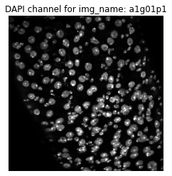

```python
import matplotlib.pyplot as plt

# display the DAPI channel for the first image
ax = plt.subplots()[1]
ax.imshow(
    exp.image_data["images"].sel(img_channels="C0", img_name="a1g01p1").compute(),
    cmap="gray",
    vmax=12000,
)
ax.set_title("DAPI channel for img_name: a1g01p1")
ax.set_axis_off()
```

{% endraw %}

We can add **segmentations** in the same fashion...

**TIP.** At a minimum, py_clone_detector requires a segmentation for the "tot_seg_ch" (see above for definition). If you do not have a suitable segmentation, check out the [example tutorial using StarDist](https://morriso1.github.io/py_clone_detective/Tutorial_StarDist_segmentation.html).

{% raw %}

```python
exp.add_segmentations(C0="data/MARCM_experiment/segmentations/C0_stardist_segs/*.tif")
```

{% endraw %}

Segmentations have now been added to the Xarray dataset:

{% raw %}

```python
exp.image_data
```

```
<xarray.Dataset>
Dimensions:        (img_channels: 4, img_name: 67, seg_channels: 1, x: 810, y: 810)
Coordinates:
  * img_channels   (img_channels) <U2 'C0' 'C1' 'C2' 'C3'
  * img_name       (img_name) <U7 'a1g01p1' 'a1g01p2' ... 'a2g13p2' 'a2g13p3'
  * y              (y) float64 0.0 0.275 0.55 0.825 ... 221.7 221.9 222.2 222.5
  * x              (x) float64 0.0 0.275 0.55 0.825 ... 221.7 221.9 222.2 222.5
  * seg_channels   (seg_channels) <U2 'C0'
Data variables:
    images         (img_channels, img_name, y, x) uint16 dask.array<chunksize=(1, 1, 810, 810), meta=np.ndarray>
    segmentations  (seg_channels, img_name, y, x) uint16 dask.array<chunksize=(1, 1, 810, 810), meta=np.ndarray>
```

{% endraw %}

### Measure cell properties

We next need to measure properties of each segmented cell (label) within our images:

{% raw %}

```python
exp.make_measurements()
```

{% endraw %}

Without providing an arguments, `CloneCounter.make_measurements()`) defaults to pairing the 'tot_seg_ch' segmentation channel to each of the image channels.

The segmentation-image channel pairs used for cell measurements can be accessed via the `CloneCounter.seg_img_channel_pairs` attribute.

{% raw %}

```python
exp.seg_img_channel_pairs
```

|  | segmentation_channel | image_channel |
| --- | --- | --- |
| 0 | C0 | C0 |
| 1 | C0 | C1 |
| 2 | C0 | C2 |
| 3 | C0 | C3 |

{% endraw %}

**TIP:** If these segmentation-image channel pairs are unsuitable for your experiment, they can be customised as detailed in the advanced tutorial (coming soon).

**TIP:** As a default,`CloneCounter.make_measurements()`) calculates every cell's mean intensity, centroid, and area. If we require additional measurements, we can supply the `extra_properties` with a list containing any 'regionprops' metrics from the [scikit-image measure module](https://scikit-image.org/docs/dev/api/skimage.measure.html). For example, we can additionally calculate 'eccentricity' as follows:

{% raw %}

```python
exp.make_measurements(extra_properties=["eccentricity"])
```

{% endraw %}

The primary result from the `CloneCounter.make_measurements()`) call is a `CloneCounter.results_measurements` attribute. This is a pandas DataFrame containing all per cell measurements.

{% raw %}

```python
exp.results_measurements
```

|  | seg_ch | int_img_ch | seg_img | int_img | label | area | mean_intensity | centroid-0 | centroid-1 | eccentricity | area_um2 |
| --- | --- | --- | --- | --- | --- | --- | --- | --- | --- | --- | --- |
| 0 | C0 | C0 | a1g01p1 | a1g01p1 | 1 | 346 | 1144.604046 | 5.054913 | 97.182081 | 0.917838 | 26.166250 |
| 1 | C0 | C0 | a1g01p1 | a1g01p1 | 2 | 574 | 2557.510453 | 7.952962 | 223.238676 | 0.867292 | 43.408750 |
| 2 | C0 | C0 | a1g01p1 | a1g01p1 | 3 | 608 | 3160.207237 | 13.875000 | 519.351974 | 0.515510 | 45.980000 |
| 3 | C0 | C0 | a1g01p1 | a1g01p1 | 4 | 173 | 2825.052023 | 7.283237 | 644.699422 | 0.635806 | 13.083125 |
| 4 | C0 | C0 | a1g01p1 | a1g01p1 | 5 | 168 | 2858.904762 | 5.690476 | 385.523810 | 0.863300 | 12.705000 |
| ... | ... | ... | ... | ... | ... | ... | ... | ... | ... | ... | ... |
| 289 | C0 | C3 | a2g13p3 | a2g13p3 | 290 | 613 | 96.443719 | 792.845024 | 551.652529 | 0.499582 | 46.358125 |
| 290 | C0 | C3 | a2g13p3 | a2g13p3 | 291 | 410 | 76.739024 | 794.009756 | 459.451220 | 0.377639 | 31.006250 |
| 291 | C0 | C3 | a2g13p3 | a2g13p3 | 292 | 675 | 31.414815 | 798.114074 | 786.000000 | 0.698885 | 51.046875 |
| 292 | C0 | C3 | a2g13p3 | a2g13p3 | 293 | 599 | 95.011686 | 799.739566 | 500.397329 | 0.690486 | 45.299375 |
| 293 | C0 | C3 | a2g13p3 | a2g13p3 | 294 | 150 | 48.766667 | 805.913333 | 633.293333 | 0.925589 | 11.343750 |

87128 rows × 11 columns

{% endraw %}

### Testing out thresholds

We now aim to determine whether each cell resides inside or outside a "clone". To do this, we first define a 'threshold' that categorises whether a cell is GFP positive or negative. This can be as simple as "mean_intensity > 1000", or involve multiple conditions e.g. "mean_intensity > 1000 & eccentricity > 0.3".

**N.B.** The threshold in this example is not being applied directly to the C1 image. Instead, for every label of the total segmentation channel (in this case C0: DAPI), we look at its corresponding intensity in the C1 (GFP) channel. We do this by querying the `CloneCounter.results_measurement` dataframe and keeping only those labels that meet our desired threshold criteria.

The `CloneCounter` class provides a helper method `testing_possible_thresholds` that can plot and compare different thresholds:

{% raw %}

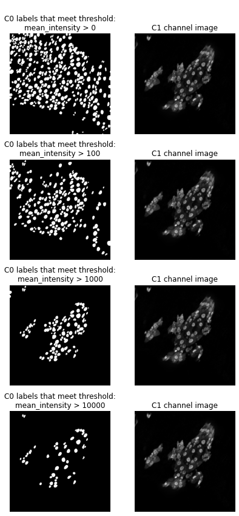

```python
exp.testing_possible_thresholds(
    int_img="a1g10p1",
    int_img_ch="C1",
    seg_img_ch="C0",
    threshold_list=[0, 100, 1000, 10000],
    threshold_query="mean_intensity > threshold_list",
)
```

{% endraw %}

From this test, we can see that a mean intensity threshold of 1000 appears roughly suitable, as its binary image on the left keeps most of the GFP positive cells, while excluding GFP negative cells.

If we were still unhappy with this as a simple threshold, we could increase stringency by adding another threshold on a different cell measurement. Below, we keep a mean intensity threshold constant at 1000, while varying an additional eccentricity threshold:

{% raw %}

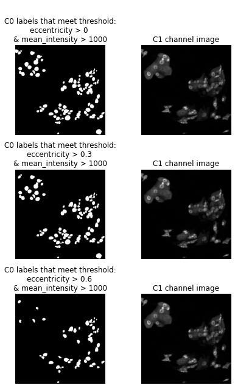

```python
exp.testing_possible_thresholds(
    int_img="a1g01p1",
    int_img_ch="C1",
    seg_img_ch="C0",
    threshold_list=[0, 0.3, 0.6],
    threshold_constant=1000,
    threshold_query="eccentricity > threshold_list & mean_intensity > threshold_constant",
)
```

{% endraw %}

In this example, most cells are pretty round and so both eccentricity == 0 and eccentricity == 0.3 look suitable.

### Add clones and calculate the number of touching neighbours

Once we have decided on a threshold, we can plug it into the `CloneCounter.add_clones_and_neighbouring_labels` method and apply it to all images:

{% raw %}

```python
exp.add_clones_and_neighbouring_labels(
    query_for_pd='int_img_ch == "C1" & seg_ch == "C0" & eccentricity > 0.3 & mean_intensity > 1000',
    name_for_query="GFP",
    calc_clones=True,
)
```

{% endraw %}

This method call does a couple of things:

1) It updates CloneCounter.results_measurements with an additional boolean column describing whether a cell (label) is positive or negative for the desired threshold.

{% raw %}

```python
exp.results_measurements.head()
```

|  | seg_ch | int_img_ch | seg_img | int_img | label | area | mean_intensity | centroid-0 | centroid-1 | eccentricity | area_um2 | GFP_pos |
| --- | --- | --- | --- | --- | --- | --- | --- | --- | --- | --- | --- | --- |
| 0 | C0 | C0 | a1g01p1 | a1g01p1 | 1 | 346 | 1144.604046 | 5.054913 | 97.182081 | 0.917838 | 26.16625 | False |
| 1 | C0 | C1 | a1g01p1 | a1g01p1 | 1 | 346 | 66.199422 | 5.054913 | 97.182081 | 0.917838 | 26.16625 | False |
| 2 | C0 | C2 | a1g01p1 | a1g01p1 | 1 | 346 | 777.419075 | 5.054913 | 97.182081 | 0.917838 | 26.16625 | False |
| 3 | C0 | C3 | a1g01p1 | a1g01p1 | 1 | 346 | 44.170520 | 5.054913 | 97.182081 | 0.917838 | 26.16625 | False |
| 4 | C0 | C0 | a1g01p1 | a1g01p1 | 2 | 574 | 2557.510453 | 7.952962 | 223.238676 | 0.867292 | 43.40875 | False |

{% endraw %}

{% raw %}

```python
exp.image_data
```

```
<xarray.Dataset>
Dimensions:         (GFP_neighbours: 7, img_channels: 4, img_name: 67, seg_channels: 1, x: 810, y: 810)
Coordinates:
  * img_channels    (img_channels) <U2 'C0' 'C1' 'C2' 'C3'
  * img_name        (img_name) <U7 'a1g01p1' 'a1g01p2' ... 'a2g13p2' 'a2g13p3'
  * y               (y) float64 0.0 0.275 0.55 0.825 ... 221.7 221.9 222.2 222.5
  * x               (x) float64 0.0 0.275 0.55 0.825 ... 221.7 221.9 222.2 222.5
  * seg_channels    (seg_channels) <U2 'C0'
  * GFP_neighbours  (GFP_neighbours) <U23 'extended_tot_seg_labels' ... 'GFPp...
Data variables:
    images          (img_channels, img_name, y, x) uint16 dask.array<chunksize=(1, 1, 810, 810), meta=np.ndarray>
    segmentations   (seg_channels, img_name, y, x) uint16 dask.array<chunksize=(1, 1, 810, 810), meta=np.ndarray>
    GFP             (GFP_neighbours, img_name, y, x) uint16 dask.array<chunksize=(7, 1, 810, 810), meta=np.ndarray>
```

{% endraw %}

To illustrate what these new images are, lets plot and walkthrough them for one `img_name`. As all these new images derive from the original total segmentation image, we will plot this as well.

Below is a little function to help with plotting:

{% raw %}

```python
def plot_new_images(
    images, label_letter, label_text, figure_shape, colorbar=False, **kwargs,
):
    from itertools import zip_longest

    fig, ax = plt.subplots(
        nrows=figure_shape[0],
        ncols=figure_shape[1],
        figsize=(figure_shape[1] * 4, figure_shape[0] * 4),
    )

    for (img, ax, letter, text) in zip_longest(
        images, ax.flatten(), label_letter, label_text
    ):
        if img is not None:
            im = ax.imshow(img, **kwargs)
            ax.set_title(f"({letter}) {text}")
            ax.axis("off")
        else:
            ax.set_axis_off()
    if colorbar:
        fig2, cax = plt.subplots(figsize=(figure_shape[1], 1))
        plt.colorbar(im, cax=cax, orientation="horizontal")
        cax.set_title("number of neighbours")
        fig.axes.append(cax)

    plt.tight_layout()
```

{% endraw %}

Now lets grab and plot the total segmenatation image and new images for `img_name` = 'a1g01p1'.

{% raw %}

```python
import numpy as np

# grab one img_name from dataset
img = exp.image_data.sel(img_name="a1g01p1")

# concentenate both the total segmentation and the new images for easy plotting
img_to_plot = np.concatenate(
    [img["segmentations"].data.compute(), img["GFP"].data.compute()]
)

# create text labels for our plot
text_labels = ["total_segmentation"] + img["GFP"].coords[
    "GFP_neighbours"
].values.tolist()
```

{% endraw %} {% raw %}

```python
import matplotlib

colors = np.random.rand(256, 3)
colors[0, :] = 0
new_map = matplotlib.colors.LinearSegmentedColormap.from_list("new_map", colors)
```

{% endraw %} {% raw %}

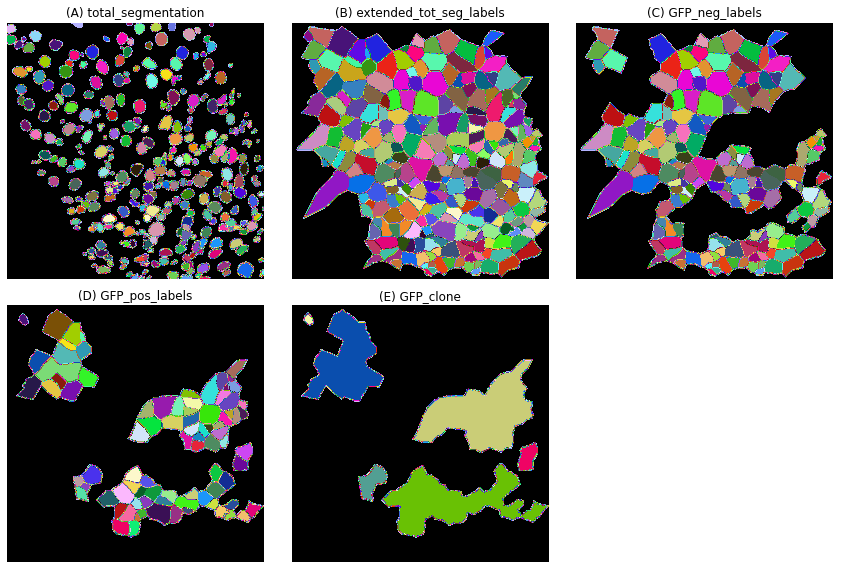

```python
plot_new_images(
    img_to_plot[:5], "ABCDE", text_labels[:5], figure_shape=(2, 3), cmap=new_map
)
```

{% endraw %}

{% raw %}

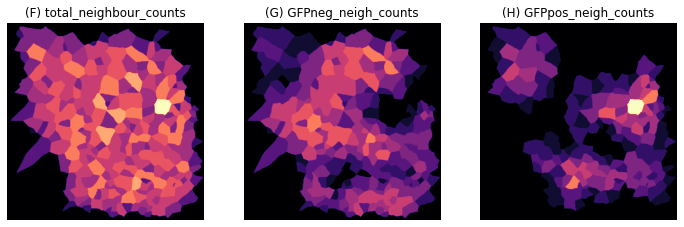

```python
plot_new_images(
    img_to_plot[5:],
    "FGH",
    text_labels[5:],
    (1, 3),
    vmax=np.unique(img_to_plot[5]).shape[0],
    colorbar=True,
    cmap="magma",
)
```

{% endraw %}

(F) - Parametric image where the number of total neighbours is mapped to color.  
(G) - Parametric image where the number of C1neg neighbours is mapped to color.  
(H) - Parametric image where the number of C1pos neighbours is mapped to color.

### Calculate number of touching neighbours for remaining non-clone image channels

{% include image.html width="400" max-width="400" file="/py_clone_detective/docs/images/labelled_cell_types.png" %}

> Cropped image of intestine stained with DAPI, PDM1 and Prospero with labelled cell types

First, we define a threshold for EC cells. Since EC are large absorptive cells, we can use total intensity rather than mean intensity for thresholding:

{% raw %}

```python
exp.results_measurements = exp.results_measurements.eval(
    "total_intensity = mean_intensity * area"
)
```

{% endraw %} {% raw %}

```python
exp.add_clones_and_neighbouring_labels(
    query_for_pd='int_img_ch == "C2" & seg_ch == "C0" & total_intensity > 5e5',
    name_for_query="EC",
    calc_clones=False,
)
```

{% endraw %}

Next, we define our EE cell type:

{% raw %}

```python
exp.add_clones_and_neighbouring_labels(
    query_for_pd='int_img_ch == "C3" & seg_ch == "C0" & mean_intensity > 5000',
    name_for_query="EE",
    calc_clones=False,
)
```

{% endraw %}

We also define a preEC cell type, which have large nuclei but are not positive for PDM1 staining or Prospero staining.

{% raw %}

```python
exp.add_clones_and_neighbouring_labels(
    query_for_pd="not EC_pos & not EE_pos & area_um2 > 50",
    name_for_query="preEC",
    calc_clones=False,
)
```

{% endraw %}

Finally, we define a progenitor cell population of Intestinal Stem Cells (ISCs) and EnteroBlasts (EBs). These have small nuclei and are negative for Prospero and PDM1 staining.

{% raw %}

```python
exp.add_clones_and_neighbouring_labels(
    query_for_pd="not EC_pos & not EE_pos & area_um2 < 50",
    name_for_query="ISCorEB",
    calc_clones=False,
)
```

{% endraw %}

### Quantify clone and the touching neighbours

We now quantify numbers of clones and touching neighbours.

{% raw %}

```python
exp.measure_clones_and_neighbouring_labels(name_for_query="GFP")
exp.measure_clones_and_neighbouring_labels(name_for_query="EC")
exp.measure_clones_and_neighbouring_labels(name_for_query="EE")
exp.measure_clones_and_neighbouring_labels(name_for_query="preEC")
exp.measure_clones_and_neighbouring_labels(name_for_query="ISCorEB")
```

{% endraw %}

These operations create a `CloneCounter.results_clones_and_neighbour_counts` attribute. This is a dictionary of pandas dataframes for each defined cell type.

{% raw %}

```python
exp.results_clones_and_neighbour_counts.keys()
```

```
dict_keys(['GFP', 'EC', 'EE', 'preEC', 'ISCorEB'])
```

{% endraw %}

Each dataframe contains neighbour count information for that cell type e.g.

{% raw %}

```python
exp.results_clones_and_neighbour_counts["GFP"].head()
```

| int_img | GFP_neighbours label | GFP_clone | GFPneg_neigh_counts | GFPpos_neigh_counts | total_neighbour_counts |
| --- | --- | --- | --- | --- | --- |
| a1g01p1 | 11 | 0 | 2 | 2 | 4 |
|  | 12 | 0 | 4 | 0 | 4 |
|  | 15 | 0 | 2 | 0 | 2 |
|  | 17 | 2 | 2 | 0 | 2 |
|  | 18 | 0 | 2 | 0 | 2 |

{% endraw %}

Next, we combine these dataframes together, along with the original `CloneCounter.results_measurements` dataframe, to return a final tidy dataframe that contains information on all cell properties (e.g. mean_intensity), whether a cell inside a clone, and the number and type of neighbours a cell has:

{% raw %}

```python
df = exp.combine_neighbour_counts_and_measurements()
```

{% endraw %}

### Data Wrangling and Plotting

Now for the fun bit, wrangling the data and plotting our results! Below, we do this using pandas, matplotlib, seaborn and some convenience functions from `py_clone_detective.clone_analysis`. However, at this stage, the output dataframe can easily be exported as csv for use in other data wrangling and plotting tools (e.g. R, Excel etc).

{% raw %}

```python
df.to_csv("data/example_results.csv")
```

{% endraw %} {% raw %}

```python
import re

import pandas as pd

from py_clone_detective import clone_analysis as ca

# to help slice multi-index dataframes
idx = pd.IndexSlice
```

{% endraw %}

#### Cell Proliferation - number of cells per clone

First, we wish to determine whether there is a difference in the number of cells per clone. To do this, we first query an intensity image channel so that we do not count a cell (label) multiple times. Next, for simplicity, filter out columns not required for counting the number and type of cells per clone.

{% raw %}

```python
count_df = df.query('int_img_ch == "C1"').filter(regex=r"clone$|pos$|int_img")
```

{% endraw %}

Next, we groupby clones per image and sum to get the number of cells of each type per clone.

{% raw %}

```python
count_df = count_df.groupby(["int_img", "GFP_clone"]).sum().reset_index()
count_df.head()
```

|  | int_img | GFP_clone | GFP_pos | EC_pos | EE_pos | preEC_pos | ISCorEB_pos |
| --- | --- | --- | --- | --- | --- | --- | --- |
| 0 | a1g01p1 | 0 | 0 | 74 | 1 | 1 | 100 |
| 1 | a1g01p1 | 1 | 14 | 9 | 0 | 0 | 5 |
| 2 | a1g01p1 | 2 | 1 | 0 | 0 | 0 | 1 |
| 3 | a1g01p1 | 3 | 4 | 1 | 0 | 0 | 3 |
| 4 | a1g01p1 | 4 | 34 | 13 | 0 | 0 | 21 |

{% endraw %}

We can add a sum all cell types per clone to get an additional 'total' column:

{% raw %}

```python
count_df.columns = [re.sub("_pos", "", col) for col in count_df.columns]
# drop the unneeded "GFP column"
count_df = count_df.drop(columns="GFP")
# calculate the total cell
count_df = count_df.eval("total = EC + preEC + EE + ISCorEB")
```

{% endraw %}

Since where "GFP_clone" == 0, we can add an additional column stating whether a "GFP_clone" is inside a clone (*IC*) or outside a clone (*OC*):

{% raw %}

```python
count_df["clone_status"] = np.where(count_df["GFP_clone"] == 0, "OC", "IC")
```

{% endraw %}

Finally, the images are named 'a1' if from a wild-type (*ctrl*) animal and 'a2' if from a mutant (*mut*) animal. We can therefore add a 'genotype' column:

{% raw %}

```python
count_df["genotype"] = np.where(count_df["int_img"].str.match(r"a1"), "ctrl", "mut")
```

{% endraw %}

We can groupby this genotype column and generate a stacked bar plot displaying cell numbers and types per clone. Here, we only interested in plotting cells inside clones, and so we first query on 'clone_status':

{% raw %}

```python
count_df_inside = count_df.query('clone_status == "IC"')

inside_clone_mean = (
    count_df_inside[["genotype", "ISCorEB", "preEC", "EC", "EE"]]
    .groupby("genotype")
    .mean()
)

inside_clone_sem = (
    count_df_inside[["genotype", "ISCorEB", "preEC", "EC", "EE"]]
    .groupby("genotype")
    .sem()
)
```

{% endraw %} {% raw %}

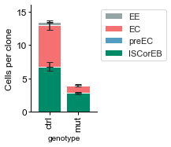

```python
ca.create_stack_bar_plot(
    inside_clone_mean,
    inside_clone_sem,
    x_figSize=1.5,
    color_pal=["#008b68", "#539DC2", "#F57171", "#95a5a6"],
    bar_width=0.8,
    y_axis_limit=16,
    y_label="Cells per clone",
)
```

{% endraw %}

{% raw %}

```python
import statsmodels.api as sm
from statsmodels.formula.api import ols
```

{% endraw %} {% raw %}

```python
lm = ols("total ~ genotype", data=count_df_inside).fit()
lm.t_test_pairwise("genotype").result_frame
```

|  | coef | std err | t | P>\|t\| | Conf. Int. Low | Conf. Int. Upp. | pvalue-hs | reject-hs |
| --- | --- | --- | --- | --- | --- | --- | --- | --- |
| mut-ctrl | -9.338462 | 1.263799 | -7.389196 | 7.841122e-13 | -11.822504 | -6.854419 | 7.841505e-13 | True |

{% endraw %}

Yes, the total number of cell per clone is significantly different in "ctrl" vs "mutant" animals.

#### Cell Differentiation - percentage cell type inside and outside clones

Next, let's investigate whether the types of cells inside and outside clones are different in ctrl and mutant animals. This information will help us determine whether our gene of interest affects **cell differentiation**.

First, since we already know that 'mutant' clones possess fewer cells than 'ctrl' clones, it is helpful to summarise cell types as a percentage.

{% raw %}

```python
percentage_df = count_df.eval(
    """EC = EC / total * 100
    EE = EE / total * 100
    preEC = preEC / total * 100
    ISCorEB = ISCorEB / total * 100"""
)
```

{% endraw %}

Next, we plot a stacked barplot as before. However, this time we plot percentage cell types:

{% raw %}

```python
percentage_df_mean = (
    percentage_df[["genotype", "clone_status", "ISCorEB", "preEC", "EC", "EE"]]
    .groupby(["clone_status", "genotype"])
    .mean()
)

percentage_df_sem = (
    percentage_df[["genotype", "clone_status", "ISCorEB", "preEC", "EC", "EE"]]
    .groupby(["clone_status", "genotype"])
    .sem()
)
```

{% endraw %} {% raw %}

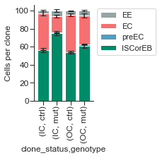

```python
ca.create_stack_bar_plot(
    percentage_df_mean,
    percentage_df_sem,
    x_figSize=1.5,
    color_pal=["#008b68", "#539DC2", "#F57171", "#95a5a6"],
    bar_width=0.8,
    y_label="Cells per clone",
)
```

{% endraw %}

This plot suggests there might be a difference in percentage cell-types of mutant clones vs ctrl. Let's check if these differences are statistically significant.

To do this, we reshape our percentage data into a tidy format:

{% raw %}

```python
tidy_percentage_df = pd.melt(
    percentage_df,
    id_vars=["genotype", "clone_status"],
    value_vars=["EC", "preEC", "EE", "ISCorEB"],
    var_name="cell_type",
    value_name="perc_cell_num",
)
tidy_percentage_df.head()
```

|  | genotype | clone_status | cell_type | perc_cell_num |
| --- | --- | --- | --- | --- |
| 0 | ctrl | OC | EC | 42.045455 |
| 1 | ctrl | IC | EC | 64.285714 |
| 2 | ctrl | IC | EC | 0.000000 |
| 3 | ctrl | IC | EC | 25.000000 |
| 4 | ctrl | IC | EC | 38.235294 |

{% endraw %}

We then create a composite column that contains genotype (g), clone_status (cs) and cell_type (ct) information.

{% raw %}

```python
tidy_percentage_df["comp_g_cs_ct"] = (
    tidy_percentage_df["genotype"]
    + "_"
    + tidy_percentage_df["clone_status"]
    + "_"
    + tidy_percentage_df["cell_type"]
)
tidy_percentage_df.head()

tidy_percentage_df["comp_g_cs_ct"] = tidy_percentage_df["comp_g_cs_ct"].astype(
    "category"
)
```

{% endraw %}

Using statsmodels and patsy, we set up a ContrastMatrix for our desired comparisons.

Our first set of contrasts compares the percentage of each cell type inside mutant vs ctrl clones:

{% raw %}

```python
contrasts = [
    "mut_IC_EC-ctrl_IC_EC",
    "mut_IC_EE-ctrl_IC_EE",
    "mut_IC_preEC-ctrl_IC_preEC",
    "mut_IC_ISCorEB-ctrl_IC_ISCorEB",
]
```

{% endraw %}

We are also interested in comparing the percentage of each cell type outside mutant vs ctrl clones.

*Reminder*: cells outside mutant clones will be heterozygous for the mutation.

{% raw %}

```python
contrasts = contrasts + [
    "mut_OC_EC-ctrl_OC_EC",
    "mut_OC_EE-ctrl_OC_EE",
    "mut_OC_preEC-ctrl_OC_preEC",
    "mut_OC_ISCorEB-ctrl_OC_ISCorEB",
]
```

{% endraw %}

Finally, we would like to compare the percentage of each cell type outside mutant vs inside mutant clones.

{% raw %}

```python
contrasts = contrasts + [
    "mut_OC_EC-mut_IC_EC",
    "mut_OC_EE-mut_IC_EE",
    "mut_OC_preEC-mut_IC_preEC",
    "mut_OC_ISCorEB-mut_IC_ISCorEB",
]
```

{% endraw %}

Below is a helper function to construct the values of contrast matrix:

{% raw %}

```python
def create_contrast_matrix(desired_contrasts, df_column):
    l = list()
    levels = pd.Series(df_column.cat.categories.values)
    for contrast in desired_contrasts:
        group_A, group_B = contrast.split("-")
        l.append(levels.replace({group_A: -1, group_B: 1, ".": 0}, regex=True))
    return np.stack(l, axis=1)
```

{% endraw %}

We can now setup a custom contrast matrix using patsy:

{% raw %}

```python
matrix = create_contrast_matrix(contrasts, tidy_percentage_df["comp_g_cs_ct"])

from patsy.contrasts import ContrastMatrix

c_matrix = ContrastMatrix(matrix=matrix, column_suffixes=contrasts)
c_matrix
```

```
ContrastMatrix(array([[ 1,  0,  0,  0,  0,  0,  0,  0,  0,  0,  0,  0,  0,  0,  0,  0],
                      [ 0,  1,  0,  0,  0,  0,  0,  0,  0,  0,  0,  0,  0,  0,  0,  0],
                      [ 0,  0,  0,  1,  0,  0,  0,  0,  0,  0,  0,  0,  0,  0,  0,  0],
                      [ 0,  0,  1,  0,  0,  0,  0,  0,  0,  0,  0,  0,  0,  0,  0,  0],
                      [ 0,  0,  0,  0,  1,  0,  0,  0,  0,  0,  0,  0,  0,  0,  0,  0],
                      [ 0,  0,  0,  0,  0,  1,  0,  0,  0,  0,  0,  0,  0,  0,  0,  0],
                      [ 0,  0,  0,  0,  0,  0,  0,  1,  0,  0,  0,  0,  0,  0,  0,  0],
                      [ 0,  0,  0,  0,  0,  0,  1,  0,  0,  0,  0,  0,  0,  0,  0,  0],
                      [-1,  0,  0,  0,  0,  0,  0,  0, -1,  0,  0,  0,  1,  0,  0,  0],
                      [ 0, -1,  0,  0,  0,  0,  0,  0,  0, -1,  0,  0,  0,  1,  0,  0],
                      [ 0,  0,  0, -1,  0,  0,  0,  0,  0,  0,  0, -1,  0,  0,  0,  1],
                      [ 0,  0, -1,  0,  0,  0,  0,  0,  0,  0, -1,  0,  0,  0,  1,  0],
                      [ 0,  0,  0,  0, -1,  0,  0,  0,  1,  0,  0,  0, -1,  0,  0,  0],
                      [ 0,  0,  0,  0,  0, -1,  0,  0,  0,  1,  0,  0,  0, -1,  0,  0],
                      [ 0,  0,  0,  0,  0,  0,  0, -1,  0,  0,  0,  1,  0,  0,  0, -1],
                      [ 0,  0,  0,  0,  0,  0, -1,  0,  0,  0,  1,  0,  0,  0, -1,  0]]),
               ['mut_IC_EC-ctrl_IC_EC',
                'mut_IC_EE-ctrl_IC_EE',
                'mut_IC_preEC-ctrl_IC_preEC',
                'mut_IC_ISCorEB-ctrl_IC_ISCorEB',
                'mut_OC_EC-ctrl_OC_EC',
                'mut_OC_EE-ctrl_OC_EE',
                'mut_OC_preEC-ctrl_OC_preEC',
                'mut_OC_ISCorEB-ctrl_OC_ISCorEB',
                'mut_IC_EC-mut_OC_EC',
                'mut_IC_EE-mut_OC_EE',
                'mut_IC_preEC-mut_OC_preEC',
                'mut_IC_ISCorEB-mut_OC_ISCorEB',
                'mut_OC_EC-mut_IC_EC',
                'mut_OC_EE-mut_IC_EE',
                'mut_OC_preEC-mut_IC_preEC',
                'mut_OC_ISCorEB-mut_IC_ISCorEB'])
```

{% endraw %}

Finally, we construct a 'ordinary least squares' (ols) model using statsmodels and test our desired contrasts:

{% raw %}

```python
lm = ols("perc_cell_num ~ C(comp_g_cs_ct, c_matrix)-1", data=tidy_percentage_df).fit()
lm.summary()
```

OLS Regression Results

| Dep. Variable: | perc_cell_num | R-squared (uncentered): | 0.416 |
| --- | --- | --- | --- |
| Model: | OLS | Adj. R-squared (uncentered): | 0.413 |
| Method: | Least Squares | F-statistic: | 117.2 |
| Date: | Thu, 19 Aug 2021 | Prob (F-statistic): | 3.04e-220 |
| Time: | 17:22:20 | Log-Likelihood: | -9744.5 |
| No. Observations: | 1984 | AIC: | 1.951e+04 |
| Df Residuals: | 1972 | BIC: | 1.958e+04 |
| Df Model: | 12 |  |  |
| Covariance Type: | nonrobust |  |  |

|  | coef | std err | t | P>\|t\| | [0.025 | 0.975] |
| --- | --- | --- | --- | --- | --- | --- |
| C(comp_g_cs_ct, c_matrix)mut_IC_EC-ctrl_IC_EC | 31.1481 | 2.272 | 13.710 | 0.000 | 26.693 | 35.604 |
| C(comp_g_cs_ct, c_matrix)mut_IC_EE-ctrl_IC_EE | 1.3078 | 2.272 | 0.576 | 0.565 | -3.148 | 5.763 |
| C(comp_g_cs_ct, c_matrix)mut_IC_preEC-ctrl_IC_preEC | -0.0628 | 2.272 | -0.028 | 0.978 | -4.518 | 4.393 |
| C(comp_g_cs_ct, c_matrix)mut_IC_ISCorEB-ctrl_IC_ISCorEB | 37.9282 | 2.272 | 16.695 | 0.000 | 33.473 | 42.384 |
| C(comp_g_cs_ct, c_matrix)mut_OC_EC-ctrl_OC_EC | -15.2925 | 4.286 | -3.568 | 0.000 | -23.698 | -6.887 |
| C(comp_g_cs_ct, c_matrix)mut_OC_EE-ctrl_OC_EE | -3.5044 | 4.286 | -0.818 | 0.414 | -11.909 | 4.901 |
| C(comp_g_cs_ct, c_matrix)mut_OC_preEC-ctrl_OC_preEC | -0.5777 | 4.286 | -0.135 | 0.893 | -8.983 | 7.827 |
| C(comp_g_cs_ct, c_matrix)mut_OC_ISCorEB-ctrl_OC_ISCorEB | -50.8409 | 4.286 | -11.863 | 0.000 | -59.246 | -42.436 |
| C(comp_g_cs_ct, c_matrix)mut_IC_EC-mut_OC_EC | -20.6024 | 1.486 | -13.866 | 0.000 | -23.516 | -17.688 |
| C(comp_g_cs_ct, c_matrix)mut_IC_EE-mut_OC_EE | -3.2115 | 1.486 | -2.161 | 0.031 | -6.125 | -0.298 |
| C(comp_g_cs_ct, c_matrix)mut_IC_preEC-mut_OC_preEC | -0.1024 | 1.486 | -0.069 | 0.945 | -3.016 | 2.812 |
| C(comp_g_cs_ct, c_matrix)mut_IC_ISCorEB-mut_OC_ISCorEB | -48.8783 | 1.486 | -32.897 | 0.000 | -51.792 | -45.964 |
| C(comp_g_cs_ct, c_matrix)mut_OC_EC-mut_IC_EC | 20.6024 | 1.486 | 13.866 | 0.000 | 17.688 | 23.516 |
| C(comp_g_cs_ct, c_matrix)mut_OC_EE-mut_IC_EE | 3.2115 | 1.486 | 2.161 | 0.031 | 0.298 | 6.125 |
| C(comp_g_cs_ct, c_matrix)mut_OC_preEC-mut_IC_preEC | 0.1024 | 1.486 | 0.069 | 0.945 | -2.812 | 3.016 |
| C(comp_g_cs_ct, c_matrix)mut_OC_ISCorEB-mut_IC_ISCorEB | 48.8783 | 1.486 | 32.897 | 0.000 | 45.964 | 51.792 |

| Omnibus: | 445.230 | Durbin-Watson: | 1.388 |
| --- | --- | --- | --- |
| Prob(Omnibus): | 0.000 | Jarque-Bera (JB): | 929.103 |
| Skew: | 1.294 | Prob(JB): | 1.77e-202 |
| Kurtosis: | 5.132 | Cond. No. | 2.21e+16 |

Notes:  
[1] R² is computed without centering (uncentered) since the model does not contain a constant.  
[2] Standard Errors assume that the covariance matrix of the errors is correctly specified.  
[3] The smallest eigenvalue is 1.67e-30. This might indicate that there are  
strong multicollinearity problems or that the design matrix is singular.

{% endraw %}

**Alternative approach:**  
If we did not have specific contrast we were interested, we could perform FDR adjusted pairwise t-tests for all possible comparisons:

{% raw %}

```python
lm = smf.ols("perc_cell_num ~ comp_g_cs_ct", tidy_percentage_df).fit()
stat_df = lm.t_test_pairwise("comp_g_cs_ct", method="fdr_bh").result_frame.reset_index()
# clean up column names
stat_df = stat_df.rename(
    columns={"index": "comparisons", "pvalue-fdr_bh": "pvalue_fdr_bh", "reject-fdr_bh":"reject_fdr_bh"}
)

stat_df.head()
```

|  | comparisons | coef | std err | t | P>\|t\| | Conf. Int. Low | Conf. Int. Upp. | pvalue_fdr_bh | reject_fdr_bh |
| --- | --- | --- | --- | --- | --- | --- | --- | --- | --- |
| 0 | ctrl_IC_EE-ctrl_IC_EC | -38.305810 | 2.294371 | -16.695562 | 1.255696e-58 | -42.805461 | -33.806158 | 9.417720e-58 | True |
| 1 | ctrl_IC_ISCorEB-ctrl_IC_EC | 15.114012 | 2.294371 | 6.587432 | 5.726200e-11 | 10.614360 | 19.613663 | 1.090705e-10 | True |
| 2 | ctrl_IC_preEC-ctrl_IC_EC | -40.919283 | 2.294371 | -17.834642 | 4.545324e-66 | -45.418934 | -36.419631 | 4.545324e-65 | True |
| 3 | ctrl_OC_EC-ctrl_IC_EC | 0.342318 | 4.210434 | 0.081302 | 9.352098e-01 | -7.915060 | 8.599696 | 9.510608e-01 | False |
| 4 | ctrl_OC_EE-ctrl_IC_EC | -36.421580 | 4.210434 | -8.650314 | 1.047014e-17 | -44.678958 | -28.164202 | 2.617535e-17 | True |

{% endraw %}

Filtering to look at our favourite comparisons:

{% raw %}

```python
stat_df.query("comparisons in @contrasts")
```

|  | comparisons | coef | std err | t | P>\|t\| | Conf. Int. Low | Conf. Int. Upp. | pvalue_fdr_bh | reject_fdr_bh |
| --- | --- | --- | --- | --- | --- | --- | --- | --- | --- |
| 7 | mut_IC_EC-ctrl_IC_EC | -22.738055 | 2.196693 | -10.351040 | 1.736493e-24 | -27.046143 | -18.429967 | 6.128799e-24 | True |
| 22 | mut_IC_EE-ctrl_IC_EE | 3.571779 | 2.196693 | 1.625980 | 1.041139e-01 | -0.736309 | 7.879868 | 1.388186e-01 | False |
| 36 | mut_IC_ISCorEB-ctrl_IC_ISCorEB | 18.864522 | 2.196693 | 8.587692 | 1.773340e-17 | 14.556434 | 23.172611 | 4.342875e-17 | True |
| 49 | mut_IC_preEC-ctrl_IC_preEC | 0.301753 | 2.196693 | 0.137367 | 8.907546e-01 | -4.006335 | 4.609842 | 9.135945e-01 | False |
| 61 | mut_OC_EC-ctrl_OC_EC | -8.902681 | 5.536138 | -1.608103 | 1.079730e-01 | -19.759989 | 1.954627 | 1.423820e-01 | False |
| 72 | mut_OC_EE-ctrl_OC_EE | 0.831434 | 5.536138 | 0.150183 | 8.806356e-01 | -10.025874 | 11.688742 | 9.110023e-01 | False |
| 82 | mut_OC_ISCorEB-ctrl_OC_ISCorEB | 7.090839 | 5.536138 | 1.280828 | 2.004051e-01 | -3.766469 | 17.948147 | 2.585872e-01 | False |
| 91 | mut_OC_preEC-ctrl_OC_preEC | 0.980407 | 5.536138 | 0.177092 | 8.594541e-01 | -9.876901 | 11.837715 | 8.968217e-01 | False |
| 95 | mut_OC_EC-mut_IC_EC | 14.177692 | 4.212662 | 3.365495 | 7.787462e-04 | 5.915945 | 22.439440 | 1.139629e-03 | True |
| 102 | mut_OC_EE-mut_IC_EE | -0.856115 | 4.212662 | -0.203224 | 8.389808e-01 | -9.117862 | 7.405633 | 8.831377e-01 | False |
| 108 | mut_OC_ISCorEB-mut_IC_ISCorEB | -14.296138 | 4.212662 | -3.393611 | 7.034477e-04 | -22.557885 | -6.034391 | 1.042145e-03 | True |
| 113 | mut_OC_preEC-mut_IC_preEC | 0.974560 | 4.212662 | 0.231341 | 8.170742e-01 | -7.287187 | 9.236308 | 8.676894e-01 | False |

{% endraw %}